# Códigos no R - Testes de Hipóteses paramétricos

# Instalando se necessário e carregando os pacotes

```r
if (!requireNamespace("BSDA", quietly = TRUE)) {install.packages("BSDA")}
if (!requireNamespace("EnvStats", quietly = TRUE)) {install.packages("BSDA")}
if (!requireNamespace("RVAideMemoire", quietly = TRUE)) {install.packages("RVAideMemoire")}
if (!requireNamespace("ggplot2", quietly = TRUE)) {install.packages("ggplot2")}
if (!requireNamespace("car", quietly = TRUE)) {install.packages("car")}
if (!requireNamespace("DescTools", quietly = TRUE)) {install.packages("DescTools")}
if (!requireNamespace("rstatix", quietly = TRUE)) {install.packages("rstatix")}

library(car)
library(BSDA)
library(EnvStats)
library(ggplot2)
library(RVAideMemoire)
library(car)
library(DescTools)
library(rstatix)
library(dplyr)
library(tidyverse)
```

# Testes de Hipótese para uma população

## Exemplo - Média Populacional - µ e $\sigma^2$ conhecido

Uma máquina é programada para encher pacotes de café, com média µ e variância igual a 400g².

Sabemos que a máquina está regulada se a quantidade média de gramas nos pacotes de café é de µ = 500g. Para verificar se a máquina está regulada, colhemos uma amostra de 25 pacotes e verificamos se a produção está sob controle, isto é, se µ = 500g ou não.

Determine se a máquina está regulada, considerando um 𝛼 = 0.01.

### Teste de Normalidade dos dados

```r
# Sample data
amostra_cafe <- c(501.58, 505.3, 497.62, 511.23, 502.13, 498.45, 496.38, 498.44, 498.45, 488.0, 508.1, 493.79, 505.24,
                492.62, 518.15, 488.77, 495.19, 510.56, 477.39, 508.69, 488.84, 503.39, 499.12, 511.97, 484.84)

# Significance level
significancia <- 0.01

# Testing the normality of the data
shapiro_test <- shapiro.test(amostra_cafe)

if (shapiro_test$p.value <= significancia) {
    cat('Rejeitamos a Hipótese Nula - Os dados não possuem dist. Normal\n')
    cat('P-valor:', round(shapiro_test$p.value, 2), '<= nível de significancia (alfa):', round(significancia, 2), '\n')
} else {
    cat('Não rejeitamos a Hipótese Nula - Os dados possuem dist. Normal\n')
    cat('P-valor:', round(shapiro_test$p.value, 2), '> nível de significancia (alfa):', round(significancia, 2), '\n')
}
```

```
## Não rejeitamos a Hipótese Nula - Os dados possuem dist. Normal
## P-valor: 0.99 > nível de significancia (alfa): 0.01
```

### Teste Z (na mão)

```r
# Dados e parâmetros
media_H0 <- 500
media_amostral <- round(mean(amostra_cafe), 2)
nivel_significancia <- 0.01
nivel_confianca <- 1 - nivel_significancia
desvio_populacional <- sqrt(400)  # Desvio padrão populacional (raiz da variância)
n <- length(amostra_cafe)

# Construir a string de informações
info_string <- sprintf("O tamanho da amostra é de: %d\n", n)
info_string <- paste(info_string, sprintf("A média amostral é: %.2f\n", media_amostral))
info_string <- paste(info_string, sprintf("O desvio padrão populacional é de: %.2f\n", desvio_populacional))
info_string <- paste(info_string, '-----------------------------------------------------------------------------------------\n')
info_string <- paste(info_string, 'Teste de Hipótese - Z\n')

# Estatística de teste
z_statistic <- (media_amostral - media_H0) / (desvio_populacional / sqrt(n))
regiao_critica <- qnorm(nivel_significancia/2)  # Rejeita se <-regiao_critica ou > regiao_critica
p_value <- 2 * pnorm(-abs(z_statistic))

info_string <- paste(info_string, sprintf('Estatística de teste: %.3f\n', z_statistic))
info_string <- paste(info_string, sprintf('Região crítica = %.3f\n', regiao_critica))
info_string <- paste(info_string, sprintf('P-valor: %.3f\n', p_value))

if (p_value < nivel_significancia) {
  info_string <- paste(info_string, "Rejeitamos a Hipótese Nula\n")
} else {
  info_string <- paste(info_string, "Não rejeitamos a Hipótese Nula\n")
}

# Exibir a string de informações
cat(info_string)
```

```
## O tamanho da amostra é de: 25
##  A média amostral é: 499.37
##  O desvio padrão populacional é de: 20.00
##  -----------------------------------------------------------------------------------------
##  Teste de Hipótese - Z
##  Estatística de teste: -0.157
##  Região crítica = -2.576
##  P-valor: 0.875
##  Não rejeitamos a Hipótese Nula
```

### Teste Z - Função pacote BSDA

Para esta função precisamos de uma amostra (coloquei uma de exemplo) por isso os resultados são diferentes.

```r
# Dados de exemplo
amostra <- c(28, 32, 25, 29, 30, 31, 27, 29, 28, 33)

# Parâmetros
media_H0 <- 30  # Valor da média populacional hipotética
sigma_conhecido <- 2     # Valor conhecido da variância populacional

# Teste de hipótese
resultado_teste <- z.test(amostra, mu = media_H0, sigma.x = sigma_conhecido)

# Exibir resultados
output <- paste(
  "Resultado do teste de hipótese:",
  "Estatística de teste (z):", round(resultado_teste$statistic,3),
  "Valor-p:", round(resultado_teste$p.value,3),
  "\nDecisão com base no valor-p:"
)

# Decisão com base no valor-p
alfa <- 0.05
if (resultado_teste$p.value < alfa) {
  output <- paste(output, "Rejeitamos a hipótese nula. ")
} else {
  output <- paste(output, "Não rejeitamos a hipótese nula.")
}

# Print the combined output
cat(output, "\n")
```

```
## Resultado do teste de hipótese: Estatística de teste (z): -1.265 Valor-p: 0.206
## Decisão com base no valor-p: Não rejeitamos a hipótese nula.
```

## Exemplo - Média Populacional - µ e $\sigma^2$ desconhecido

Um fabricante afirma que seus cigarros não contêm mais que 30 mg de nicotina. Uma amostra de 35 cigarros fornece média de 32.1 mg e desvio padrão de 2.2 mg.

No nível de 5%, os dados refutam ou não a afirmação do fabricante?

### Teste de Normalidade

```r
# Amostra de cigarro
amostra_cigarro <- c(33.81, 31.9, 30.15, 27.55, 32.87, 36.74, 31.75, 30.06, 34.3,
                     33.09, 32.87, 32.25, 32.1, 31.91, 31.13, 30.18, 33.0, 37.04,
                     34.62, 37.12, 33.3, 33.31, 30.91, 28.94, 33.51, 30.68, 31.99,
                     32.12, 31.64, 28.13, 29.21, 31.8, 32.52, 30.24, 30.57)

# Nível de significância
significancia <- 0.05

# Teste de normalidade
shapiro_test <- shapiro.test(amostra_cigarro)

if (shapiro_test$p.value <= significancia) {
    cat('Rejeitamos a Hipótese Nula - Os dados não possuem dist. Normal\n')
    cat('P-valor:', round(shapiro_test$p.value, 2), '<= nível de significância (alfa):', round(significancia, 2), '\n')
} else {
    cat('Não rejeitamos a Hipótese Nula - Os dados possuem dist. Normal\n')
    cat('P-valor:', round(shapiro_test$p.value, 2), '> nível de significância (alfa):', round(significancia, 2), '\n')
}
```

```
## Não rejeitamos a Hipótese Nula - Os dados possuem dist. Normal
## P-valor: 0.32 > nível de significância (alfa): 0.05
```

### Teste t (na mão)

```r
# Dados e parâmetros
media_H0 <- 30
media_amostral <- mean(amostra_cigarro)
desvio_amostral <- sd(amostra_cigarro)  # Desvio padrão amostral
nivel_significancia <- 0.05
nivel_confianca <- 1 - nivel_significancia

n <- length(amostra_cigarro)
graus_de_liberdade <- n - 1

# Estatística de teste t
t_statistic <- (media_amostral - media_H0) / (desvio_amostral / sqrt(n))
regiao_critica <- qt(nivel_confianca, graus_de_liberdade)  # Rejeita se <-regiao_critica ou > regiao_critica

# Calculate P(T > t)
p_value <- 1 - pt(t_statistic, graus_de_liberdade)

output <- paste(
  'Estatística de teste:', round(t_statistic, 3),
  ', Região crítica =', round(regiao_critica, 3),
  '\nP-valor:', round(p_value, 3), '\n'
)

if (p_value < significancia) {
  output <- paste(output, "Rejeitamos a Hipótese Nula\n")
} else {
  output <- paste(output, "Não rejeitamos a Hipótese Nula\n")
}

cat(output)
```

```
## Estatística de teste: 5.534 , Região crítica = 1.691
## P-valor: 0
##  Rejeitamos a Hipótese Nula
```

### Teste t (função)

```r
# Dados e parâmetros
media_H0 <- 30

# Teste de hipótese t de uma amostra
t_test_result <- t.test(amostra_cigarro, mu = media_H0, alternative = "greater")

t_test_result
```

```
##
##  One Sample t-test
##
## data:  amostra_cigarro
## t = 5.5344, df = 34, p-value = 0.000001736
## alternative hypothesis: true mean is greater than 30
## 95 percent confidence interval:
##  31.45461      Inf
## sample estimates:
## mean of x
##  32.09457
```

## Exemplo - Proporção Populacional - $p$

> o R não possui o teste Z para proporção. Ele possui: prop.test que utiliza um teste qui-quadrado e o binom.test utiliza um teste exato da dist binomial.

Uma empresa desenvolveu uma nova vacina de Covid, e afirma que a proporção de imunizados é maior do que 50%.

Em uma amostra de 726 pessoas que tomaram a vacina, 668 estavam imunizadas.

No nível de 5%, teste a afirmativa de que a proporção de imunizados é maior do que 50%.

### Teste z para proporção (na mão)

```r
# Dados e parâmetros
successes <- 668
total_trials <- 726
p0 <- 0.5
alpha = 0.05

# Calculate sample proportion
sample_proportion <- successes / total_trials

# Standard error of the proportion
se_proportion <- sqrt((p0 * (1 - p0)) / total_trials)

# Z-score
z_score <- (sample_proportion - p0) / se_proportion

# Two-tailed p-value
p_value <- 1 - pnorm(z_score)

# Display results
output <- paste(
  'One-Sample Proportion Z-Test (Manual Calculation):\n',
  '--------------------------------------------------\n',
  sprintf('Sample Proportion: %.4f\n', sample_proportion),
  sprintf('Hypothesized Proportion: %.4f\n', p0),
  '--------------------------------------------------\n',
  sprintf('Z-Score: %.4f\n', z_score),
  sprintf('P-Value: %.4f\n', p_value),
  '--------------------------------------------------\n',
  'Result: ',
  if (p_value < alpha) {
    'Reject the null hypothesis\n'
  } else {
    'Fail to reject the null hypothesis\n'
  }
)

cat(output)
```

```
## One-Sample Proportion Z-Test (Manual Calculation):
##  --------------------------------------------------
##  Sample Proportion: 0.9201
##  Hypothesized Proportion: 0.5000
##  --------------------------------------------------
##  Z-Score: 22.6392
##  P-Value: 0.0000
##  --------------------------------------------------
##  Result:  Reject the null hypothesis
```

## Exemplo - Variância Populacional - $σ^2$

Na indústria farmacêutica, baixa variabilidade é sinônimo de qualidade. Para isso, constantemente monitora-se e corrige-se a produção de medicamentos para manter níveis aceitáveis de qualidade.

Uma amostra de frascos de medicamento foi inspecionada em relação à concentração de um determinado princípio ativo na solução.

Os dados são dados por: 0.15 0.18 0.18 0.20 0.21 0.22 0.25 0.27 0.17 0.18 0.19 0.20 0.21 0.22 0.26 0.27

```r
# Dados de exemplo
amostra_medicamento <- c(0.15, 0.18, 0.18, 0.20, 0.21, 0.22, 0.25, 0.27, 0.17, 0.18, 0.19, 0.20, 0.21, 0.22, 0.26, 0.27)

# Parâmetros
nivel_significancia <- 0.05

# Teste de normalidade
shapiro_test_result <- shapiro.test(amostra_medicamento)


if (shapiro_test_result$p.value <= nivel_significancia) {
  cat('Rejeitamos a Hipótese Nula - Os dados não possuem dist. Normal\n')
  cat('P-valor: ', round(shapiro_test_result$p.value, 2),
      '<= nível de significância (alfa):', round(nivel_significancia, 2), '\n')
} else {
  cat('Não rejeitamos a Hipótese Nula - Os dados possuem dist. Normal\n')
  cat('P-valor: ', round(shapiro_test_result$p.value, 2),
      '> nível de significância (alfa):', round(nivel_significancia, 2), '\n')
}
```

```
## Não rejeitamos a Hipótese Nula - Os dados possuem dist. Normal
## P-valor:  0.32 > nível de significância (alfa): 0.05
```

```r
Chi_Test = varTest(amostra_medicamento, sigma.squared = 0.0009, alternative = "greater")
Chi_Test
```

```
##
## Results of Hypothesis Test
## --------------------------
##
## Null Hypothesis:                 variance = 0.0009
##
## Alternative Hypothesis:          True variance is greater than 0.0009
##
## Test Name:                       Chi-Squared Test on Variance
##
## Estimated Parameter(s):          variance = 0.001333333
##
## Data:                            amostra_medicamento
##
## Test Statistic:                  Chi-Squared = 22.22222
##
## Test Statistic Parameter:        df = 15
##
## P-value:                         0.1021081
##
## 95% Confidence Interval:         LCL = 0.0008001347
##                                  UCL =          Inf
```

# Testes de Hipótese para duas populações

## Exemplo - Médias de duas Populações independentes - $σ^2$ conhecidos

Uma transportadora de mercadorias tem duas possibilidades de trajeto para realizar entregas. O gerente de logística desconfia não haver diferença significativa entre o tempo de cada trajeto.

Foram selecionadas aleatoriamente 45 entregas realizadas no primeiro trajeto, resultando em uma média amostral de 57 minutos. No segundo trajeto, foram selecionadas aleatoriamente 30 entregas, e o tempo médio foi de 54 minutos.

O desvio-padrão populacional do primeiro trajeto é de $σ^2_1$ = 8 minutos, e o do segundo trajeto é de $σ^2_2$ = 6 minutos.

Teste a hipótese de que não existe diferença significativa entre o tempo médio dos dois trajetos, ao nível de 1% de significância.

Amostra_trajeto1 = [50.86, 63.98, 58.47, 74.52, 50.53, 50.28, 52.2, 40.01, 52.79, 50.93, 58.2, 59.73, 72.01, 64.6, 52.38, 49.81, 60.94, 46.44, 71.65, 66.44, 53.25, 43.29, 67.83, 56.08, 66.9, 44.24, 52.2, 57.04, 57.38, 53.4, 61.98, 48.46, 55.86, 57.96, 61.12, 62.69, 48.0, 44.73, 67.22, 59.66, 51.01, 69.41, 57.93, 66.43, 57.54]

Amostra_trajeto2 =[66.36, 64.53, 52.51, 59.83, 57.87, 62.21, 48.21, 58.12, 60.35, 43.45, 46.9, 41.76, 52.38, 58.31, 63.01, 54.44, 63.77, 45.72, 43.78, 53.67, 56.3, 53.8, 41.6, 53.47, 46.17, 58.02, 56.2, 48.36, 50.92, 47.64]

```r
Amostra_trajeto1 <- c(50.86, 63.98, 58.47, 74.52, 50.53, 50.28, 52.2, 40.01, 52.79, 50.93, 58.2, 59.73, 72.01,
                    64.6, 52.38, 49.81, 60.94, 46.44, 71.65, 66.44, 53.25, 43.29, 67.83, 56.08, 66.9, 44.24,
                    52.2, 57.04, 57.38, 53.4, 61.98, 48.46, 55.86, 57.96, 61.12, 62.69, 48.0, 44.73, 67.22,
                    59.66, 51.01, 69.41, 57.93, 66.43, 57.54)

Amostra_trajeto2 <- c(66.36, 64.53, 52.51, 59.83, 57.87, 62.21, 48.21, 58.12, 60.35, 43.45, 46.9, 41.76,
                   52.38, 58.31, 63.01, 54.44, 63.77, 45.72, 43.78, 53.67, 56.3, 53.8, 41.6, 53.47,
                   46.17, 58.02, 56.2, 48.36, 50.92, 47.64)

# Two-sample z-test
z_test_result <- z.test(Amostra_trajeto1, Amostra_trajeto2, sigma.x=8, sigma.y=6,  alternative = "two.sided")

z_test_result
```

```
##
##  Two-sample z-Test
##
## data:  Amostra_trajeto1 and Amostra_trajeto2
## z = 2.1119, p-value = 0.0347
## alternative hypothesis: true difference in means is not equal to 0
## 95 percent confidence interval:
##  0.2459538 6.5936018
## sample estimates:
## mean of x mean of y
##  57.07511  53.65533
```

## Exemplo - Médias de duas Populações independentes - $σ^2$ desconhecidos - Vâriancias iguais $σ_1^2 = σ_2^2$

Em uma avaliação de estatística, foi selecionada uma amostra de 12 alunos da turma A, resultando em uma média de 7.9 com desvio-padrão 0.6.

Na turma B, foram selecionados 15 alunos, os quais tiraram nota média 6.7 com desvio-padrão 0.8.

Foram feitos testes de normalidade e igualdade das variâncias e determinou se que as notas possuem distribuição normal e $σ_1^2 = σ_2^2$,

Teste a hipótese de que a turma A tem média maior do que a turma B, com um nível de significância de 1%.

TurmaA = [8.04, 7.76, 7.8, 8.46, 8.82, 7.88, 7.4, 7.05, 8.63, 8.25, 8.01, 6.94]

TurmaB = [7.94, 6.07, 6.44, 7.35, 5.72, 6.88, 7.75, 5.41, 6.85, 6.91, 7.33, 5.71, 5.64, 7.12, 6.94]

```r
TurmaA = c(8.04, 7.76, 7.8, 8.46, 8.82, 7.88, 7.4, 7.05, 8.63, 8.25, 8.01, 6.94)
TurmaB = c(7.94, 6.07, 6.44, 7.35, 5.72, 6.88, 7.75, 5.41, 6.85, 6.91, 7.33, 5.71, 5.64, 7.12, 6.94)
```

### Teste de Normalidade

```r
# Significance level
significancia <- 0.01

# Testing the normality of the data
shapiro_test_A  <- shapiro.test(TurmaA)

shapiro_test_A
```

```
##
##  Shapiro-Wilk normality test
##
## data:  TurmaA
## W = 0.96578, p-value = 0.862
```

```r
shapiro_test_B  <- shapiro.test(TurmaB)
shapiro_test_B
```

```
##
##  Shapiro-Wilk normality test
##
## data:  TurmaB
## W = 0.93788, p-value = 0.3565
```

### Teste de Homogeneidade

```r
# Bartlett test
bartlett_test_result <- bartlett.test(list(TurmaA, TurmaB))
bartlett_test_result
```

```
##
##  Bartlett test of homogeneity of variances
##
## data:  list(TurmaA, TurmaB)
## Bartlett's K-squared = 1.117, df = 1, p-value = 0.2906
```

### Teste de hipotese independente - Vâriancias iguais $σ_1^2 = σ_2^2$

```r
# Realizar o teste t de Student para médias independentes
t_test_result <- t.test(TurmaA, TurmaB, alternative = "greater", var.equal = TRUE,
       conf.level = 0.99)

t_test_result
```

```
##
##  Two Sample t-test
##
## data:  TurmaA and TurmaB
## t = 4.519, df = 25, p-value = 0.00006483
## alternative hypothesis: true difference in means is greater than 0
## 99 percent confidence interval:
##  0.5622915       Inf
## sample estimates:
## mean of x mean of y
##  7.920000  6.670667
```

```r
# Nível de significância
nivel_significancia <- 0.01

# Decision based on the p-value
if (t_test_result$p.value < nivel_significancia) {
  cat('Result: Reject the null hypothesis. The mean of TurmaA is significantly greater than the mean of TurmaB.\n')
} else {
  cat('Result: Fail to reject the null hypothesis. We cannot claim that the mean of TurmaA is greater than the mean of TurmaB.\n')
}
```

```
## Result: Reject the null hypothesis. The mean of TurmaA is significantly greater than the mean of TurmaB.
```

## Exemplo - Médias de duas Populações independentes - $σ^2$ desconhecidos - Vâriancias diferentes $σ_1^2 \neq σ_2^2$

Uma pesquisa avaliou a eficácia de dois tipos de treinamento, com a finalidade de reduzir o tempo médio de determinada tarefa doméstica.

Foram selecionadas duas amostras aleatórias e determinou-se através de testes de hipóteses que as populações possuem distribuição normal e $σ_1^2 \neq σ_2^2$.

Treinamento1 = [19.7, 23.36, 22.84, 26.06, 19.15, 25.66, 30.6, 19.89, 24.8, 22.11, 25.55, 24.26, 22.17, 25.74, 29.9]

Treinamento2 = [16.06, 25.63, 36.46, 14.7, 23.74, 27.1, 24.52, 23.33, 17.4, 25.06]

```r
Treinamento1 <- c(19.7, 23.36, 22.84, 26.06, 19.15, 25.66, 30.6, 19.89, 24.8, 22.11, 25.55, 24.26, 22.17, 25.74, 29.9)

Treinamento2 <- c(16.06, 25.63, 36.46, 14.7, 23.74, 27.1, 24.52, 23.33, 17.4, 25.06)


# Significance level
significancia <- 0.01

# Testing the normality of the data
shapiro_test_Treinamento1 <- shapiro.test(Treinamento1)

shapiro_test_Treinamento1
```

```
##
##  Shapiro-Wilk normality test
##
## data:  Treinamento1
## W = 0.94674, p-value = 0.4746
```

```r
shapiro_test_Treinamento2  <- shapiro.test(Treinamento2)
shapiro_test_Treinamento2
```

```
##
##  Shapiro-Wilk normality test
##
## data:  Treinamento2
## W = 0.91515, p-value = 0.3182
```

### Teste de Homogeneidade

```r
# Bartlett test
bartlett_test_result <- bartlett.test(list(Treinamento1, Treinamento2))
bartlett_test_result
```

```
##
##  Bartlett test of homogeneity of variances
##
## data:  list(Treinamento1, Treinamento2)
## Bartlett's K-squared = 4.2474, df = 1, p-value = 0.03931
```

### Teste de hipotese independente - Vâriancias diferentes $σ_1^2 \neq σ_2^2$

```r
# Realizar o teste t de Student para médias independentes
t_test_result <- t.test(TurmaA, TurmaB, alternative = "greater", var.equal = FALSE, conf.level = 0.95)


t_test_result
```

[output not shown]

## Teste de hipotese Dependente - Média de duas populações dependentes

### Exemplo: manutenção preventiva

Em uma fábrica, sete máquinas foram selecionadas aleatoriamente a fim de determinar o efeito da manutenção preventiva na produção.

Inicialmente, as máquinas trabalharam por um período na forma habitual, e depois trabalham o mesmo período recebendo manutenções preventivas.

O total de trabalho produzido, antes e depois da adoção das manutenções, está na tabela ao lado.

Ao nível de 5%, podemos concluir que o trabalho médio produzido é maior depois da adoção das manutenções preventivas?

dados_antes = [12.10, 12.30, 11.10, 12.80, 14.10, 8.40, 13.30]

dados_depois = [12.50, 16.00, 12.90, 14.00, 12.90, 12.50, 13.50]

```r
dados_antes = c(12.10, 12.30, 11.10, 12.80, 14.10, 8.40, 13.30)
dados_depois = c(12.50, 16.00, 12.90, 14.00, 12.90, 12.50, 13.50)

diferenca = dados_antes - dados_depois

shapiro_test<- shapiro.test(diferenca)
shapiro_test
```

```
##
##  Shapiro-Wilk normality test
##
## data:  diferenca
## W = 0.94726, p-value = 0.7047
```

```r
t_test_result <- t.test(dados_antes, dados_depois, paired = TRUE, alternative='less')
t_test_result
```

```
##
##  Paired t-test
##
## data:  dados_antes and dados_depois
## t = -2.0153, df = 6, p-value = 0.04524
## alternative hypothesis: true mean difference is less than 0
## 95 percent confidence interval:
##         -Inf -0.05214273
## sample estimates:
## mean difference
##       -1.457143
```

## Exemplo - Proporções de duas Populações Independentes

Em um estudo com 2870 motoristas, 1210 afirmaram ter o hábito de mexer no celular com o carro em movimento. Depois de sancionada uma multa, foi realizado outro estudo com 2200 motoristas, dos quais 725 afirmaram ter ainda o hábito.

Usando um nível de significância de 10%, é possível verificar a alegação de que a proporção de motoristas com hábito de mexer no celular no trânsito diminuiu significativamente após a criação da multa?

p = proporção de motorista que usam o celular com o carro em movimento.

$$\begin{cases} H_0 = p_1 - p_2 = 0\\H_1
= p_1 - p_2 > 0 \end{cases}$$

> O R NÃO POSSUI UM TESTE Z PARA PROPORÇÕES, É NECESSÁRIO IMPLEMENTAR.

```r
# Function to calculate Z-test for proportions
proportions_ztest <- function(successes1, total1, successes2, total2, alpha = 0.05, alternative = "two-sided") {
  # Calculate sample proportions
  p1 <- successes1 / total1
  p2 <- successes2 / total2

  # Pooled sample proportion
  p_pooled <- (successes1 + successes2) / (total1 + total2)

  # Calculate standard error
  se <- sqrt(p_pooled * (1 - p_pooled) * ((1 / total1) + (1 / total2)))

  # Calculate Z-statistic
  z_statistic <- (p1 - p2) / se

  # Decision based on the p-value
  if (alternative == "two-sided") {
    p_value = 2 * (1 - pnorm(abs(z_statistic)))
    critical_value = qnorm(1 - alpha / 2)
  } else if (alternative == "less") {
    p_value = pnorm(z_statistic)
    critical_value = qnorm(alpha)
  } else if (alternative == "greater") {
    p_value = 1 - pnorm(z_statistic)
    critical_value = qnorm(1 - alpha)
  } else {
    stop("The 'alternative' argument must be 'two-sided', 'less', or 'greater'.")
  }

  # Display results
  cat(paste("Z-score:", round(z_statistic, 2), "\n"))
  cat(paste("P-value:", round(p_value, 4), "\n"))
  cat(paste("Critical value:", round(critical_value, 2), "\n"))

  # Decision based on the p-value
  if (p_value < alpha) {
    cat("Result: Reject the null hypothesis.\n")
  } else {
    cat("Result: Fail to reject the null hypothesis.\n")
  }
}


# Given data
successes1 <- 1210
total1 <- 2870
successes2 <- 725
total2 <- 2200

# Call the custom function
proportions_ztest(successes1, total1, successes2, total2, alpha = 0.10, alternative = "greater")
```

```
## Z-score: 6.69
## P-value: 0
## Critical value: 1.28
## Result: Reject the null hypothesis.
```

## Variâncias de duas populações

Nos EUA, as moedas de quarto de dólar sofreram alterações no peso depois de 1964.

Uma amostra de 40 moedas fabricadas antes de 1964 resultou em um desvio-padrão de 0.087 g. Uma amostra de 40 moedas fabricadas depois de 1964 resultou em um desvio-padrão de 0.06194 g.

Ao se projetar uma máquina de vendas com moedas, deve-se considerar os desvios-padrão antes e depois de 1964.

Use o nível de significância de 5% para testar a afirmativa de que os pesos de quarto de dólar antes e depois de 1964 são provenientes de populações com o mesmo desvio-padrão

```r
# Given data
Antes_1964 <- c(6.31, 6.3, 6.35, 6.16, 6.06, 6.33, 6.19, 6.08, 6.27, 6.33,
                6.25, 6.22, 6.25, 6.23, 6.14, 6.2, 6.31, 6.29, 6.27, 6.17,
                6.24, 6.07, 6.28, 6.38, 6.13, 6.21, 6.29, 6.37, 6.22, 6.2,
                6.09, 6.27, 6.44, 6.28, 6.26, 6.29, 6.26, 6.19, 6.33, 6.28)

Depois_1964 <- c(6.31, 6.36, 6.21, 6.29, 6.32, 6.26, 6.12, 6.28, 6.31, 6.2, 6.24, 6.19, 6.1, 6.32,
                 6.26, 6.36, 6.31, 6.24, 6.25, 6.3, 6.32, 6.28, 6.33, 6.24, 6.2, 6.26, 6.27, 6.19,
                 6.18, 6.29, 6.23, 6.25, 6.24, 6.35, 6.34, 6.18, 6.23, 6.32, 6.3, 6.3)

# Testing the normality of the data
shapiro_test_Antes_1964 <- shapiro.test(Antes_1964)

shapiro_test_Antes_1964
```

```
##
##  Shapiro-Wilk normality test
##
## data:  Antes_1964
## W = 0.97456, p-value = 0.4953
```

```r
shapiro_test_Depois_1964  <- shapiro.test(Depois_1964)
shapiro_test_Depois_1964
```

```
##
##  Shapiro-Wilk normality test
##
## data:  Depois_1964
## W = 0.9596, p-value = 0.1623
```

```r
# Perform F-test for variances
var_test_result <- var.test(Antes_1964, Depois_1964)
var_test_result
```

```
##
##  F test to compare two variances
##
## data:  Antes_1964 and Depois_1964
## F = 1.9682, num df = 39, denom df = 39, p-value = 0.03741
## alternative hypothesis: true ratio of variances is not equal to 1
## 95 percent confidence interval:
##  1.040965 3.721261
## sample estimates:
## ratio of variances
##           1.968172
```

# Testes de Hipótese para 3 OU MAIS populações

## ANOVA UMA VIA

$$\begin{cases} H_0: \mu_1 = \mu_2 = \mu_3
...= \mu_k \text{ (todas as médias são iguais)}\\H_1: \text{Pelo menos
uma é diferente das demais} \end{cases}$$

```r
# Read CSV file in R
dados_tratamentos <- read.csv('Hipertensao.csv', sep = ';', dec = ',')

# Display the first 5 rows
head(dados_tratamentos)
```

```
##   Sujeito   Grupo Pressao     BC Triglicerides Glicemia
## 1      21 Placebo  175.33 356.33         65.84       93
## 2      30 Placebo  158.00 378.00        148.15      109
## 3      27 Placebo  163.67 397.33        115.23      112
## 4      20 Placebo  184.67 435.33         76.54      113
## 5      31 Placebo  171.67 365.33         73.25      115
## 6      28 Placebo  192.67 376.67         85.60      116
```

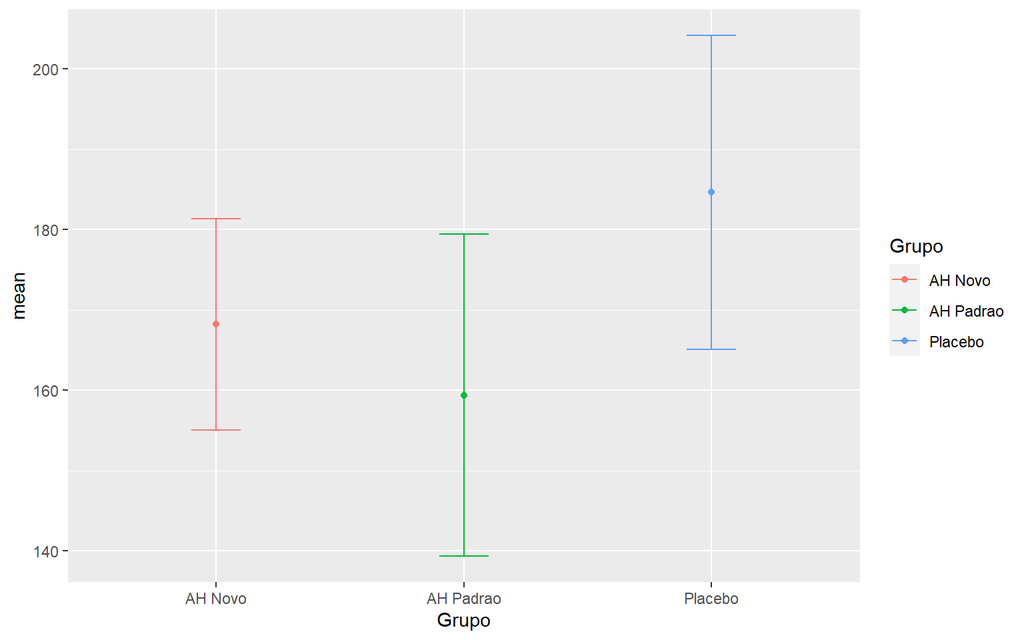

```r
# create a new dataframe crop_means
Calculatemeans <- dados_tratamentos %>%
  group_by(Grupo) %>%
  summarize(mean=mean(Pressao),
            std = sd(Pressao))

ggplot(Calculatemeans, aes(x=Grupo, y=mean, color=Grupo)) +
  geom_point()+
  geom_errorbar(aes(ymin=mean-std, ymax=mean+std), width=.2,
                position=position_dodge(0.05))
```

#### Shapiro por grupo (pacote RVAideMemoire)

```r
byf.shapiro(Pressao ~ Grupo, dados_tratamentos)
```

```
##
##  Shapiro-Wilk normality tests
##
## data:  Pressao by Grupo
##
##                W p-value
## AH Novo   0.9053  0.2842
## AH Padrao 0.9546  0.7226
## Placebo   0.9426  0.5331
```

```r
 bartlett.test(Pressao ~ Grupo, data = dados_tratamentos)
```

```
##
##  Bartlett test of homogeneity of variances
##
## data:  Pressao by Grupo
## Bartlett's K-squared = 1.5813, df = 2, p-value = 0.4536
```

```r
anova <- aov(Pressao ~ Grupo, dados_tratamentos)
summary(anova)
```

```
##             Df Sum Sq Mean Sq F value  Pr(>F)
## Grupo        2   3631  1815.5   5.521 0.00953 **
## Residuals   28   9208   328.9
## ---
## Signif. codes:  0 '***' 0.001 '**' 0.01 '*' 0.05 '.' 0.1 ' ' 1
```

#### Post-hoc - Pacote DescTools

```r
# Uso do TukeyHSD
PostHocTest(anova, method = "hsd")
```

```
##
##   Posthoc multiple comparisons of means : Tukey HSD
##     95% family-wise confidence level
##
## $Grupo
##                        diff     lwr.ci   upr.ci   pval
## AH Padrao-AH Novo -8.823222 -29.440247 11.79380 0.5469
## Placebo-AH Novo   16.416944  -3.369521 36.20341 0.1183
## Placebo-AH Padrao 25.240167   6.027344 44.45299 0.0082 **
##
## ---
## Signif. codes:  0 '***' 0.001 '**' 0.01 '*' 0.05 '.' 0.1 ' ' 1
```

```r
# Uso do Bonferroni
PostHocTest(anova, method = "bonf")
```

```
##
##   Posthoc multiple comparisons of means : Bonferroni
##     95% family-wise confidence level
##
## $Grupo
##                        diff     lwr.ci   upr.ci   pval
## AH Padrao-AH Novo -8.823222 -30.041131 12.39469 0.8961
## Placebo-AH Novo   16.416944  -3.946198 36.78009 0.1486
## Placebo-AH Padrao 25.240167   5.467386 45.01295 0.0090 **
##
## ---
## Signif. codes:  0 '***' 0.001 '**' 0.01 '*' 0.05 '.' 0.1 ' ' 1
```

```r
# Outra opção
# pairwise.t.test(dados_tratamentos$Pressao, dados_tratamentos$Grupo, p.adj="bonferroni", paired=F)
```

## ANOVA com medidas repetidas

```r
library(tidyverse)
# Read the CSV file
notas_alunos <- read.csv('Notas_alunos.csv', sep=';', dec=',')
notas_alunos
```

```
##    Aluno Prof1 Prof2 Prof3 Prof4
## 1      1   6.2   6.4   6.1   5.8
## 2      2   7.8   7.3   7.5   7.0
## 3      3   8.1   7.5   6.9   6.5
## 4      4   9.0   8.3   7.9   7.2
## 5      5   6.0   5.2   5.4   4.8
## 6      6   3.5   2.8   3.0   2.0
## 7      7   4.3   4.0   4.9   3.5
## 8      8   8.5   8.0   8.0   7.4
## 9      9   2.4   2.5   2.2   1.5
## 10    10   9.4   9.0   8.9   8.5
## 11    11   8.3   7.8   8.0   7.4
## 12    12   7.0   7.4   7.5   8.1
## 13    13   2.9   3.4   3.0   3.5
## 14    14   6.0   5.8   5.6   5.4
```

[output cut: 16 more lines]

```r
# Melt the data
df <- notas_alunos %>%
  pivot_longer(cols = c(Prof1, Prof2, Prof3, Prof4), names_to = "Professor", values_to = "Nota")

df$Aluno = factor(df$Aluno)
glimpse(df)
```

```
## Rows: 120
## Columns: 3
## $ Aluno     <fct> 1, 1, 1, 1, 2, 2, 2, 2, 3, 3, 3, 3, 4, 4, 4, 4, 5, 5, 5, 5, …
## $ Professor <chr> "Prof1", "Prof2", "Prof3", "Prof4", "Prof1", "Prof2", "Prof3…
## $ Nota      <dbl> 6.2, 6.4, 6.1, 5.8, 7.8, 7.3, 7.5, 7.0, 8.1, 7.5, 6.9, 6.5, …
```

#### Shapiro por grupo (pacote RVAideMemoire)

```r
byf.shapiro(Nota ~ Professor, df)
```

```
##
##  Shapiro-Wilk normality tests
##
## data:  Nota by Professor
##
##            W p-value
## Prof1 0.9315 0.05394 .
## Prof2 0.9373 0.07717 .
## Prof3 0.9356 0.06938 .
## Prof4 0.9627 0.36204
## ---
## Signif. codes:  0 '***' 0.001 '**' 0.01 '*' 0.05 '.' 0.1 ' ' 1
```

### Ajuste da Anova de medidas Repetidas e teste de Esfericidade

$$\begin{cases} H_0: \mu_1 = \mu_2 =
\mu_3 = \mu_4\text{ (todas as médias são iguais)}\\H_1: \text{Pelo
menos uma é diferente das demais} \end{cases}$$

$$\begin{cases} H_0 = \text{A diferença da
média dos 4 grupos} = 0 \\H_1 = \text{A diferença da média dos 4 grupos}
\neq 0 \end{cases}$$

```r
res.aov <- ezANOVA(data = df, dv = Nota, wid = Aluno, within = Professor, detailed = FALSE, type = 3)
res.aov %>% pander::pander()
```

- **ANOVA**:

  |  | Effect | DFn | DFd | F | p | p<.05 | ges |
  | --- | --- | --- | --- | --- | --- | --- | --- |
  | **2** | Professor | 3 | 87 | 22.34 | 0.00000000008154 | * | 0.04688 |

- **Mauchly’s Test for Sphericity**:

  |  | Effect | W | p | p<.05 |
  | --- | --- | --- | --- | --- |
  | **2** | Professor | 0.3597 | 0.00003164 | * |

- **Sphericity Corrections**:

  Table continues below

  |  | Effect | GGe | p[GG] | p[GG]<.05 | HFe |
  | --- | --- | --- | --- | --- | --- |
  | **2** | Professor | 0.6146 | 0.0000001828 | * | 0.6544 |

  |  | p[HF] | p[HF]<.05 |
  | --- | --- | --- |
  | **2** | 0.00000008211 | * |

```r
pairwise.t.test(x = df$Nota, g = df$Professor, p.adjust.method="bonferroni", paired = TRUE)
```

```
##
##  Pairwise comparisons using paired t tests
##
## data:  df$Nota and df$Professor
##
##       Prof1    Prof2   Prof3
## Prof2 0.00161  -       -
## Prof3 0.01943  1.00000 -
## Prof4 0.000016 0.00033 0.00055
##
## P value adjustment method: bonferroni
```

```r
Calculatemeans = df %>% group_by(Professor) %>%
  get_summary_stats(Nota, type = 'mean_sd')

Calculatemeans
```

```
## # A tibble: 4 × 5
##   Professor variable     n  mean    sd
##   <chr>     <fct>    <dbl> <dbl> <dbl>
## 1 Prof1     Nota        30  6.45  1.91
## 2 Prof2     Nota        30  6.1   1.75
## 3 Prof3     Nota        30  6.09  1.73
## 4 Prof4     Nota        30  5.37  1.83
```

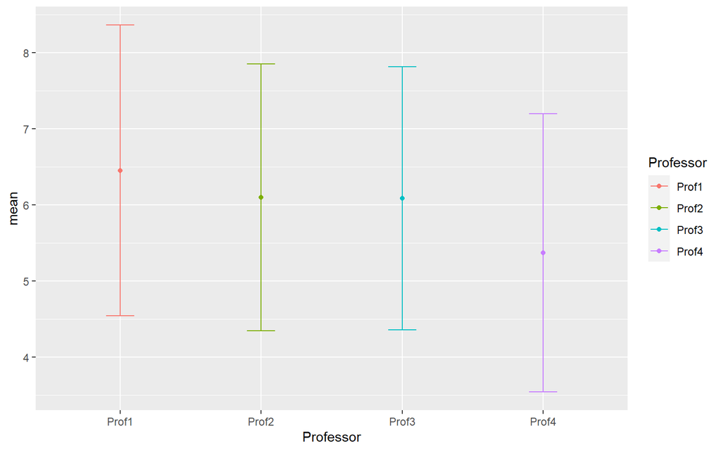

```r
# create a new dataframe crop_means
ggplot(Calculatemeans, aes(x=Professor, y=mean, color=Professor)) +
  geom_point()+
  geom_errorbar(aes(ymin=mean-sd, ymax=mean+sd), width=.2,
                position=position_dodge(0.05))
```

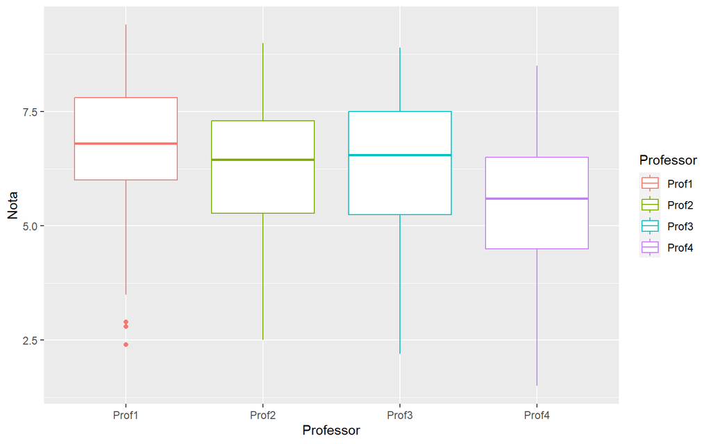

```r
ggplot(df, aes(x=Professor, y=Nota, color=Professor)) +
  geom_boxplot()
```